# Introduction to Spatial Statistics

Geostatistics

Yang Li

2026-05-22

# Classical Data

Classical (non-spatial) data is typically represented as rows and columns where observations are assumed to be independent.

| Name | Height |
| --- | --- |
| A | 5.6 |
| B | 6.0 |
| C | 5.7 |
| D | 5.9 |

Suppose this is a random sample from a population, then we can estimate the population mean (average height) by

$$\hat{\mu} = \bar{x}=\frac{5.6+6.0+5.7+5.9}{4}= 5.8$$
We can also assess the uncertainty of the estimation by its standard error

$$\text{SEM}=s/\sqrt{n}=0.091$$

Here $s$ is the sample standard deviation $s=\sqrt{\frac{1}{4-1}\sum_{i=1}^{4}(x_i-\bar{x})^2}=0.1826$.

The 95% confidence interval for $\mu$ is

$$\bar{x}\pm t_{0.975, 3}\times \text{SEM}=5.8\pm 3.182\times 0.091=(5.51,
6.09).$$

# Spatial Data

Spatial data is different

- Each observation is associated with a spatial location.
- Observations are NOT independent.

```r
set.seed(42)
vals <- runif(100) # Our 100 fixed values
vals
```

```
##   [1] 0.9148060435 0.9370754133 0.2861395348 0.8304476261 0.6417455189
##   [6] 0.5190959491 0.7365883146 0.1346665972 0.6569922904 0.7050647840
##  [11] 0.4577417762 0.7191122517 0.9346722472 0.2554288243 0.4622928225
##  [16] 0.9400145228 0.9782264284 0.1174873617 0.4749970816 0.5603327462
##  [21] 0.9040313873 0.1387101677 0.9888917289 0.9466682326 0.0824375581
##  [26] 0.5142117843 0.3902034671 0.9057381309 0.4469696281 0.8360042600
##  [31] 0.7375956178 0.8110551413 0.3881082828 0.6851697294 0.0039483388
##  [36] 0.8329160803 0.0073341469 0.2076589728 0.9066014078 0.6117786434
##  [41] 0.3795592405 0.4357715850 0.0374310329 0.9735399138 0.4317512489
##  [46] 0.9575765966 0.8877549055 0.6399787695 0.9709666104 0.6188382073
##  [51] 0.3334272113 0.3467482482 0.3984854114 0.7846927757 0.0389364911
##  [56] 0.7487953862 0.6772768302 0.1712643304 0.2610879638 0.5144129347
##  [61] 0.6756072745 0.9828171979 0.7595442676 0.5664884241 0.8496897186
##  [66] 0.1894739354 0.2712866147 0.8281584852 0.6932048204 0.2405447396
##  [71] 0.0429887960 0.1404790941 0.2163854151 0.4793985642 0.1974103423
##  [76] 0.7193558377 0.0078847387 0.3754899646 0.5144077083 0.0015705542
##  [81] 0.5816040025 0.1579052082 0.3590283059 0.6456318784 0.7758233626
##  [86] 0.5636468416 0.2337033986 0.0899805163 0.0856120649 0.3052183695
##  [91] 0.6674265147 0.0002388966 0.2085699569 0.9330341273 0.9256447486
##  [96] 0.7340943010 0.3330719834 0.5150633298 0.7439746463 0.6191592400
```

Let’s put these numbers on a grid so each number has a coordinate.

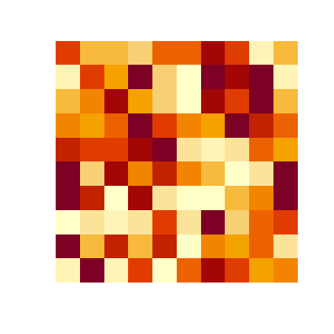

We can put the same set of values in different arrangements.

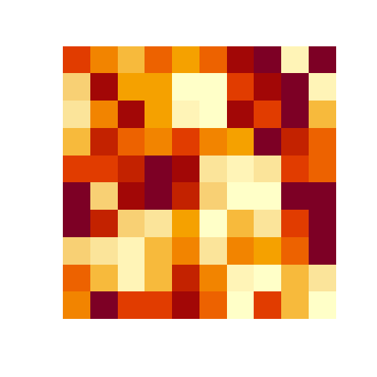

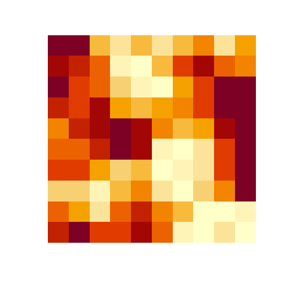

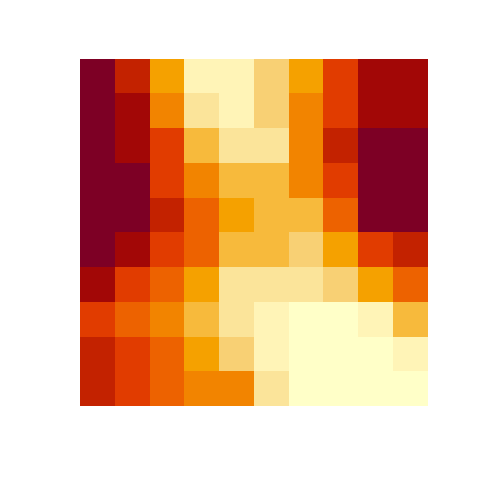

- Even though they all have the same values, the patterns are distinct.
- It means that spatial information (location) is crucial for spatial statistics.

# Types of Spatial Data

- Geostatistical data
- Lattice data
- Spatial point patterns

# Geostatistical Data

- Let $Y$ be the attribute/variable concerned in the study.
- $Y$ can be measured everywhere in a continuous domain $D$ (theoretically).
- The real data set is collected only on a finite number of $n$ locations $s_1, s_2, \dots, s_n$.
- Goal: make the most accurate predictions possible for locations where data was not collected.

## Example

Below is the average rainfall over different years for the period May-June (dry-season) in Paraná State, Brazil. It was collected at 143 recording stations.

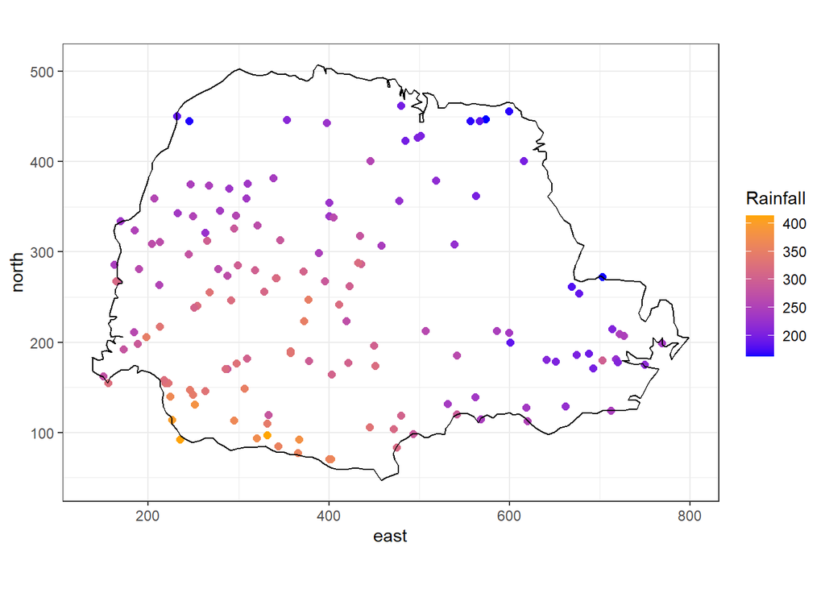

We want to predict a continuous map of rainfall for the whole state.

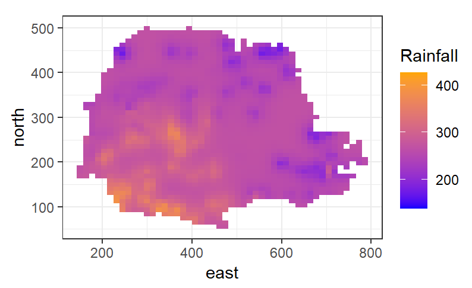

## How to predict?

If we know the observed values at $s_1, s_2, s_3$, what do you think about the value at a new location $s_0$?

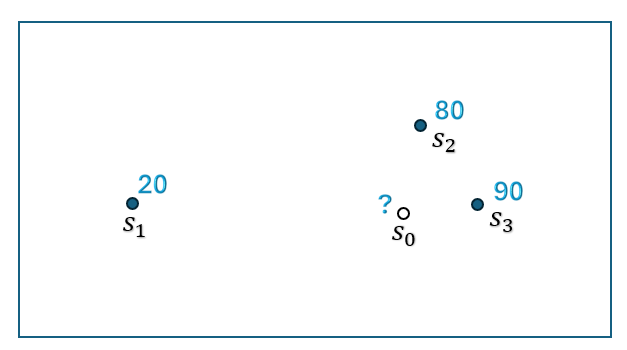

## Another Example

[figure not shown]

Temperature map in the US.

# First Law of Geography

## Waldo Tobler’s first law of geography:

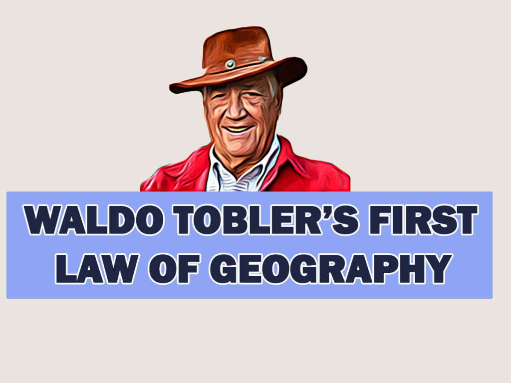

Everything is related to everything else, but near things are more related than distant things.

# Variogram

We need a concept to evaluate the strength of the relationship between the pair of observations. Spatial autocorrelation is quantified by the **variogram** $\gamma(h)$ or **covariance function** $C(h)$.

$$\gamma(h)=\frac{1}{2}\text{Var}(Z(s)-Z(s+h))$$
and

$$C(h)=\text{Cov}(Z(s), Z(s+h))$$

- $\gamma(h) \geq 0$
- $\gamma(0)=0$
- $\gamma(h)$ increases with $h$

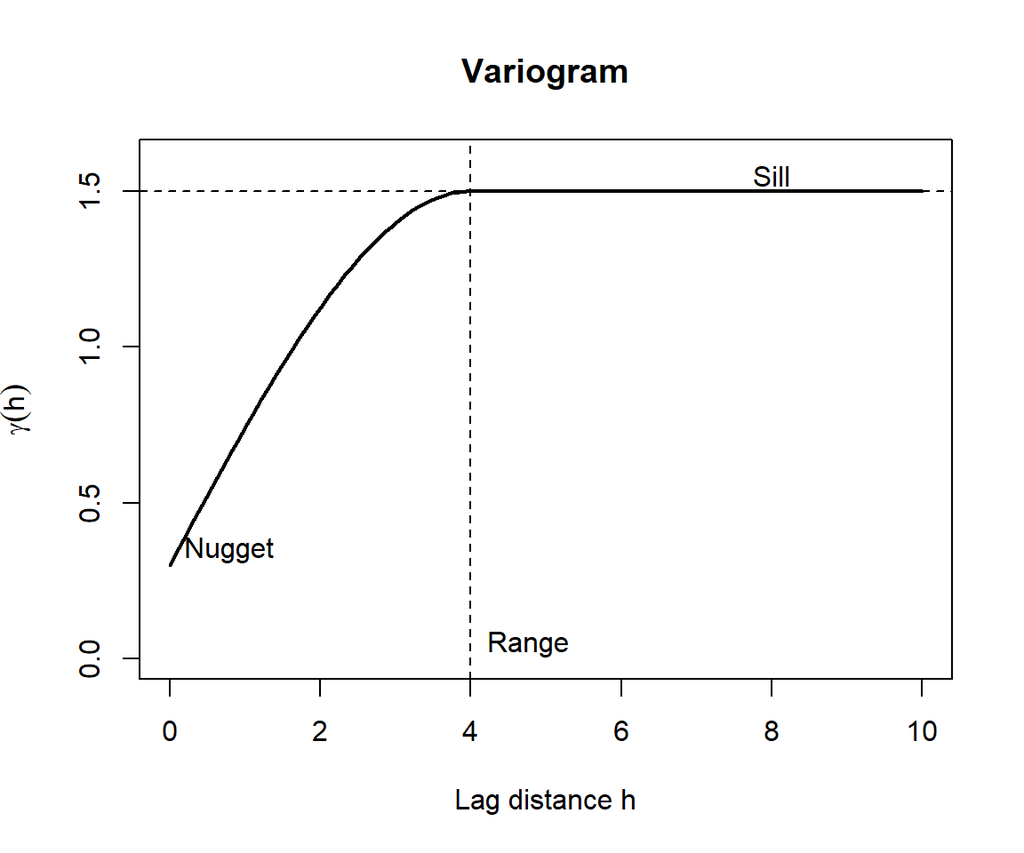

Characteristics of a variogram:

- **Nugget**: the variogram value near zero distance.
  - Measurement error
  - Microscale variation
  - Appears as a jump at the origin.
- **Sill**: the value where the variogram levels off.
  - Represents the overall variance of the process.
  - Beyond this level, spatial dependence is weak
- **Range**: the distance at which the variogram reaches the sill.
  - observations closer than the range are spatially correlated
  - observations farther apart are approximately independent

## Commonly used variogram models

- Spherical model:

$$\gamma(h)=
\begin{cases}
c_0 + c\left[
\frac{3h}{2a}
-\frac12\left(\frac{h}{a}\right)^3
\right], & h \le a \\[1em]
c_0+c, & h>a
\end{cases}$$
- Exponential Model

$$\gamma(h)
=
c_0+c\left(1-e^{-h/a}\right)$$

- Gaussian Model

$$\gamma(h)
=
c_0+c\left(1-e^{-(h/a)^2}\right)$$

- Power Model

$$\gamma(h)=c_0+bh^\alpha,
\qquad 0<\alpha<2$$

- Matérn Model

$$\gamma(h)
=
c_0 +
\sigma^2
\left[
1 -
\frac{2^{1-\nu}}{\Gamma(\nu)}
\left(
\frac{h}{\phi}
\right)^\nu
K_\nu\left(
\frac{h}{\phi}
\right)
\right]$$

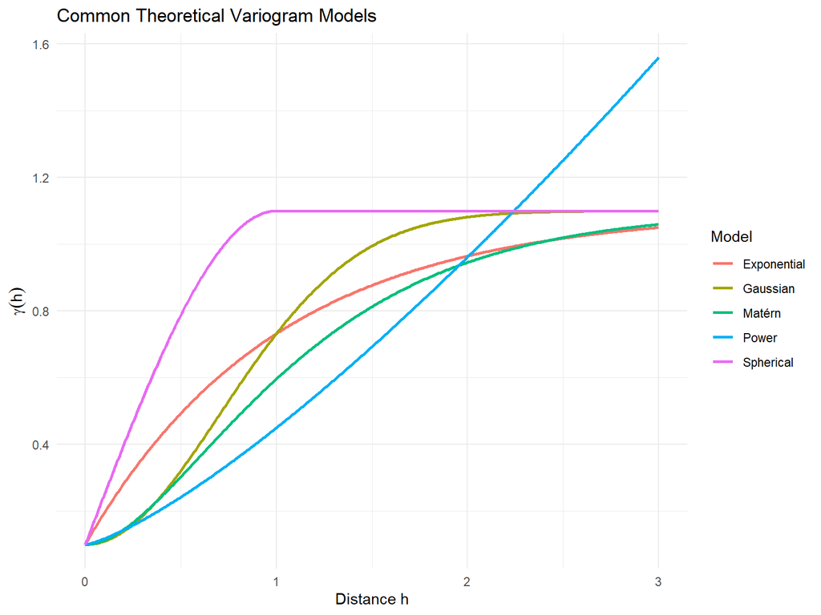

# Estimation of the Variogram

The variogram can be estimated from the data.

## Variogram Cloud

A **variogram cloud** displays the raw pairwise semivariances

$$\frac12\left[Z(s_i)-Z(s_j)\right]^2$$

against the separation distance

$$h_{ij} = \|s_i-s_j\|.$$

Unlike the empirical variogram, which averages values within distance bins, the variogram cloud shows *all* pairwise semivariances.

A typical variogram cloud looks like this.

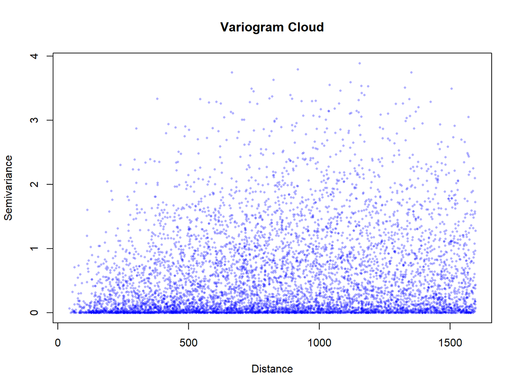

## Empirical Variogram

The empirical variogram averages the cloud values within distance bins.

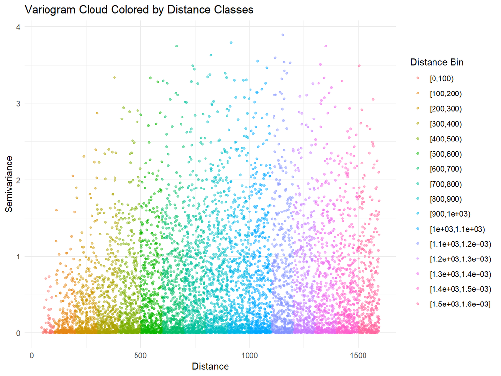

After averaging we get the empirical variogram.

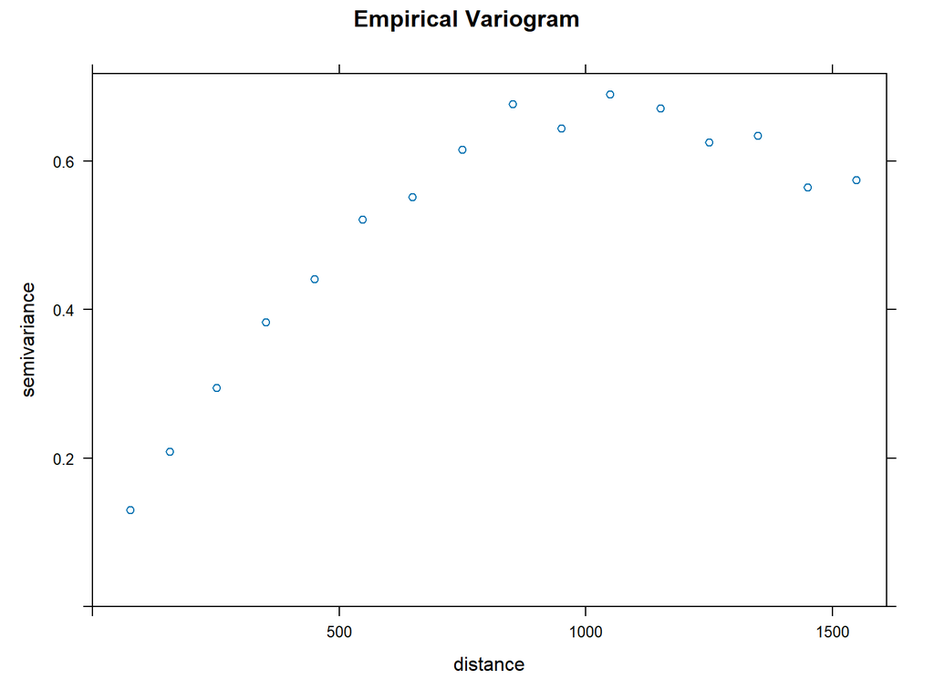

## Fit the Empirical Variogram

The empirical variogram only gives us values at several discrete distances. We need a continuous curve defined at any distance.

### Ordinary Least Squares (OLS)

One common approach is to fit the theoretical variogram model to the empirical variogram by minimizing the sum of squared differences:

$$\sum_{i=1}^m
\left[
\hat{\gamma}(h_i) - \gamma(h_i; \theta)
\right]^2$$

where:

- $\hat{\gamma}(h_i)$ is the empirical variogram value,
- $\gamma(h_i; \theta)$ is the theoretical model,
- $\theta$ represents the model parameters.

OLS is simple and computationally efficient, but it ignores the fact that empirical variogram estimates have different variances at different lag distances.

### Weighted Least Squares (WLS)

Weighted least squares improves upon OLS by assigning weights:

$$\sum_{i=1}^m
w_i
\left[
\hat{\gamma}(h_i) - \gamma(h_i; \theta)
\right]^2$$

Common choices for weights include:

- the number of point pairs in each lag bin,
- inverse variance weights.

WLS generally performs better because bins with more information receive larger weights.

In practice, the `gstat` package uses weighted least squares by default in `fit.variogram()`.

### Maximum Likelihood Estimation (MLE)

Another approach is to estimate the variogram parameters through maximum likelihood. Under the assumption of multivariate normality, the likelihood is constructed from the covariance matrix implied by the variogram model.

MLE often provides statistically efficient estimates and allows formal inference, but it can be computationally intensive because it requires repeated inversion of covariance matrices.

### Restricted Maximum Likelihood (REML)

Restricted maximum likelihood adjusts for the estimation of the mean structure. REML often produces less biased estimates of covariance parameters than MLE, especially for smaller datasets.

# Kriging

- **Kriging** is to obtain predictions at unsampled (new) locations based on observed data.
- It is named after South African mining engineer Danie G. Krige.

Suppose we know the observed values $Z(s_1), Z(s_2), \dots$ at $s_1, s_2, \dots$, what value should we predict at a new location $s_0$?

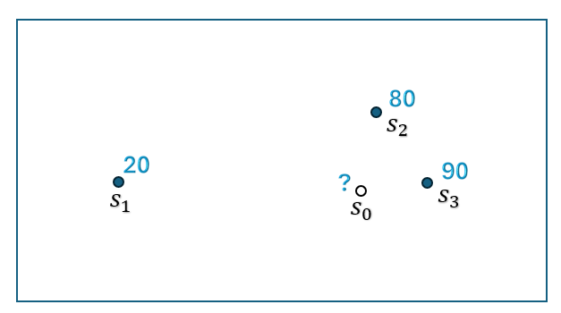

## Ordinary Kriging

If the mean is unknown and constant

$$Z(s) = \mu + \varepsilon(s),$$

we can use ordinary kriging. Its estimator is a linear combination

$$\hat{Z}(s_0)=\sum_{i=1}^{n}\lambda_i Z(s_i)$$

where coefficients (weights) $\lambda_i$ are to be determined by minimizing the mean squared prediction error

$$E[(\hat{Z}(s_0)-Z(s_0))^2]$$

- $\lambda_i$ reflects the spatial correlation of the data.
- It accounts for the geographical proximity and similarity of data points.
- Measurements $Z(s_i)$ that are more correlated and closer to $s_0$ are given more weight than those farther apart.

$\lambda_i$ are obtained by solving the ordinary kriging system

$$\begin{bmatrix}
\gamma(s_1,s_1) & \gamma(s_1,s_2) & \cdots & \gamma(s_1,s_n)
& 1 \\
\gamma(s_2,s_1) & \gamma(s_2,s_2) & \cdots & \gamma(s_2,s_n)
& 1 \\
\vdots & \vdots & \ddots & \vdots & \vdots \\
\gamma(s_n,s_1) & \gamma(s_n,s_2) & \cdots & \gamma(s_n,s_n)
& 1 \\
1 & 1 & \cdots & 1 & 0
\end{bmatrix}
\begin{bmatrix}
\lambda_1 \\
\lambda_2 \\
\vdots \\
\lambda_n \\
\mu
\end{bmatrix}
=
\begin{bmatrix}
\gamma(s_1,s_0) \\
\gamma(s_2,s_0) \\
\vdots \\
\gamma(s_n,s_0) \\
1
\end{bmatrix}$$

## Universal Kriging

Universal kriging is a spatial prediction method for data with a nonconstant mean. It assumes

$$Z(s) = m(s) + \varepsilon(s),$$

where

$$m(s) = \beta_0 + \beta_1 x_1(s) + \cdots + \beta_p x_p(s)$$

is a deterministic trend and $\varepsilon(s)$ is a spatially correlated residual process.

So universal kriging combines:

1. regression on spatial coordinates or covariates;
2. kriging of the spatially correlated residuals.

# An Illustration

```r
library(sp)
library(gstat)
library(sf)
```

```r
library(mapview)

data(meuse)
data(meuse.grid)

meuse <- st_as_sf(meuse, coords = c("x", "y"), crs = 28992)
mapview(meuse, zcol = "zinc",  map.types = "CartoDB.Voyager")
```

[interactive chart not shown]

```r
meuse.grid <- st_as_sf(meuse.grid, coords = c("x", "y"), crs = 28992)
mapview(meuse.grid,  map.types = "CartoDB.Voyager")
```

[interactive chart not shown]

The variogram cloud shows half of all possible squared differences of data observation pairs against their separation distance $h$.

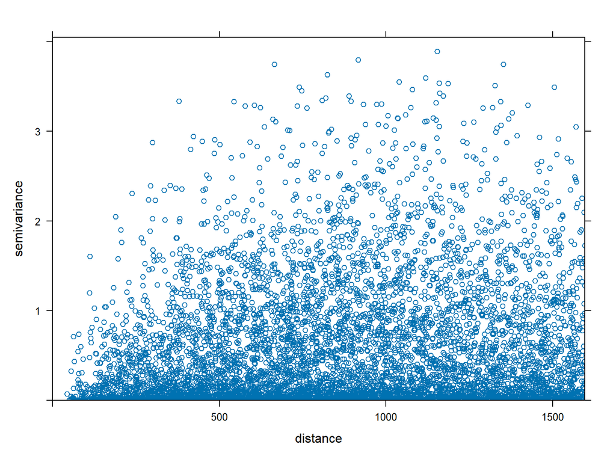

```r
vc <- variogram(log(zinc) ~ 1, meuse, cloud = TRUE)
plot(vc)
```

The sample variogram averages the variogram cloud values over distance intervals.

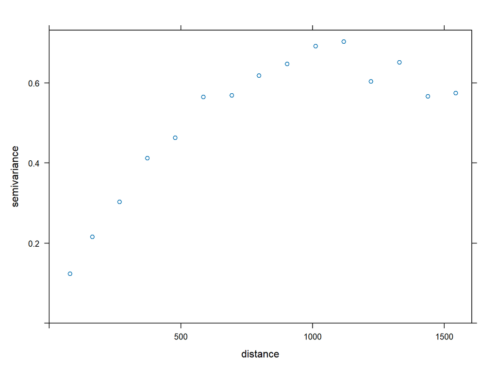

```r
v <- variogram(log(zinc) ~ 1, data = meuse)
plot(v)
```

The `fit.variogram()` function fits a variogram model to a sample variogram.

```r
fv <- fit.variogram(object = v,
                    model = vgm(psill = 0.5, model = "Sph",
                                range = 900, nugget = 0.1))
fv
```

```
##   model      psill    range
## 1   Nug 0.05066017   0.0000
## 2   Sph 0.59060556 897.0044
```

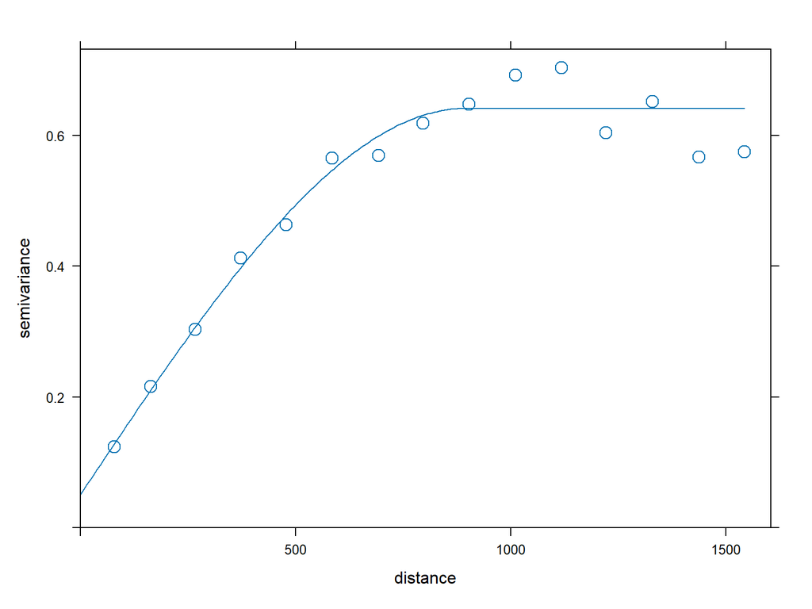

```r
plot(v, fv, cex = 1.5)
```

```r
library(viridis)
```

```r
library(ggplot2)

k <- gstat(formula = log(zinc) ~ 1, data = meuse, model = fv)
kpred <- predict(k, meuse.grid)
```

```
## [using ordinary kriging]
```

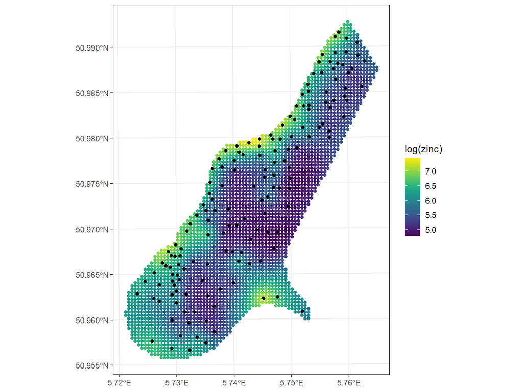

```r
ggplot() +
    geom_sf(data = kpred, aes(color = var1.pred)) +
    geom_sf(data = meuse) +
    scale_color_viridis(name = "log(zinc)") +
    theme_bw()
```

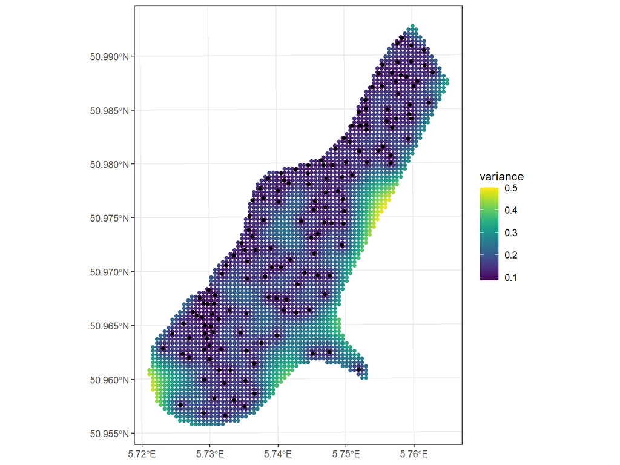

```r
ggplot() + geom_sf(data = kpred, aes(color = var1.var)) +
    geom_sf(data = meuse) +
    scale_color_viridis(name = "variance") +
    theme_bw()
```